# NOLH Problem Set

## 3.4 Hyperparameter Tuning

Latin hypercube-based designs are a good choice for studies like Army modernization program requirements analysis and for use in response surface methodology. Since we covered that ground in the previous problem set using central composite designs, we’ll instead apply a NOLH design to a hyperparameter tuning problem.

Many machine learning methods require the analyst to select initial values for various hyperparameters prior to implemeting the machine learning algorithm. The performance of the resulting machine learning model is sometimes highly sensitive to the choice of hyperparameter values. Often there are only rough rules of thumb for selecting hyperparameter values, and so analysts must rely on experience, instinct, and perhaps a bit of luck. Techniques have been developed for exploring the impacts of choices in hyperparameter values, and this process is known as hyperparameter tuning. One such technique is called a grid search where ranges of values are selected for each hyperparameter, values are selected at regular intervals between the minimums and maximums, and each combination is tested. This should sound familiar because the technique is a gridded design, which by now should cause you to cringe.

For this next problem, we’ll use an NOLH design to efficiently tune five notional hyperparameters: $\alpha$, $\beta$, $\delta$, $\eta$, and $\gamma$ (because machine learning practitioners love Greek letters as much as everyone else). For simplicity, we’ll say that each hyperparameters is a continuous number between 0 and 1.

### 3.4.1 Pairs Plot

Since the machine learning algorithms can be sensitive to our choice of hyperparameter value, create an NOLH design for these five hyperparameters with at least 1,000 design points. Ensure your columns are named alpha, beta, delta, eta, and gamma. Produce a pairs plot of your design.

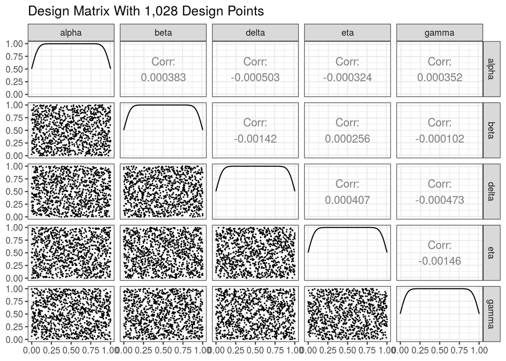

```r
dm257 = readxl::read_xls('/cloud/project/html/_Chapter10_ProblemSets/NOLHdesigns_v6.xls',
                        sheet='coded NOLH for 23-29 factors',
                        range = "B5:AD261",
                        col_names = paste('f', 1:29, sep=''))

M = matrix(1:20, nrow=4, byrow=T)
dm = dm257 %>% select(M[1, ])
colnames(dm) = c("alpha", "beta", "delta", "eta", "gamma")
for (x in 2:4){
  newdm = dm257 %>% select(M[x, ])
  colnames(newdm) = c("alpha", "beta", "delta", "eta", "gamma")
  dm = bind_rows(dm, newdm)
}

# rescale
dm = dm %>%
  mutate(
    alpha = round(scales::rescale(alpha, to=c(0, 1)), 3),
    beta = round(scales::rescale(beta, to=c(0, 1)), 3),
    delta = round(scales::rescale(delta, to=c(0, 1)), 3),
    eta = round(scales::rescale(eta, to=c(0, 1)), 3),
    gamma = round(scales::rescale(gamma, to=c(0, 1)), 3)
  )

ggpairs(dm, lower = list(continuous = wrap("points", size=0.1)), progress=FALSE) +
  ggtitle("Design Matrix With 1,028 Design Points") +
  theme_bw()
```

### 3.4.2 Get Results

Save your design as a .csv file, and upload it to the [Combat Simulator](https://cxxidemo.shinyapps.io/AWARSLite/) Shiny app. Instead of running a combat simulation for this design matrix, the Shiny app will calculate the machine learning model error and return those errors as the response variable. In the app, navigate to the tab titled “NOLH Problem Set”, upload your .csv file, and then download the results.

Next, read the data into *R*, and plot a histogram of the error. How does the error distribution look? For this to be a useful technique, we’d like to see a reasonable proportion of the error terms near zero.

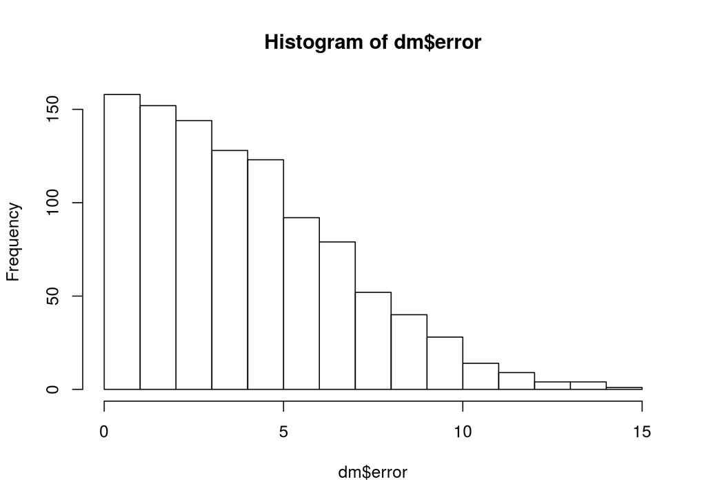

```r
# create the .csv file
# readr::write_csv(dm %>% select(alpha, beta, delta, eta, gamma), "/cloud/project/html/_Chapter10_ProblemSets/hyper.csv")
# do the simulation
# read the results back in
dm = read.csv("/cloud/project/html/_Chapter10_ProblemSets/hyper_out.csv", sep=',', header=TRUE)

hist(dm$error)
```

```r
# the lowest errors are the most frequest, so the technique appears promising.
```

### 3.4.3 Lowest Error

What was the lowest error you measured, and what were the associated hyperparameter values?

```r
dm %>% filter(error==min(error))
```

```
##   alpha  beta delta   eta gamma       error
## 1 0.117 0.398  0.84 0.957 0.719 0.004992378
```

### 3.4.4 Ground Truth

The hyperparameter values that will actually produce the lowest error are:

- $\alpha$: 0.2016819
- $\beta$: 0.8983897
- $\delta$: 0.9446753
- $\eta$: 0.6607978
- $\gamma$: 0.6291140

How close were your results to these values?

```r
# beta was the farthest off, followed by eta. The others weren't too far off.
```